# hw1-andrew-oconnor

### 1) Data “storms”

```r
library(tidyverse)
```

### 2) Storms in 2015

1. Write a “dplyr” command to create a table (i.e tibble) `storms2015` containing the storms that took place in the year 2015.

```r
storms2015 <- filter(storms, year == 2015)
```

2. With `storms2015`, write a command that returns only the name of unique storms in 2015. In other words, the output should display only the unique names and nothing else.

```r
storms2015 %>%
  group_by(name) %>%
  distinct(name)
```

```
## # A tibble: 11 × 1
## # Groups:   name [11]
##    name
##    <chr>
##  1 Ana
##  2 Bill
##  3 Claudette
##  4 Danny
##  5 Erika
##  6 Fred
##  7 Henri
##  8 Nine
##  9 Ida
## 10 Joaquin
## 11 Kate
```

3. With `storms2015`, write a command that returns a table with the name of each unique storm and the number of times it appears. In other words, this is a table with two columns: 1) name of the storm, and 2) the number of counts of each storm

```r
storms2015 %>%
  distinct(name, year) %>%
  count(name)
```

```
## # A tibble: 11 × 2
##    name          n
##    <chr>     <int>
##  1 Ana           1
##  2 Bill          1
##  3 Claudette     1
##  4 Danny         1
##  5 Erika         1
##  6 Fred          1
##  7 Henri         1
##  8 Ida           1
##  9 Joaquin       1
## 10 Kate          1
## 11 Nine          1
```

4. With `storms2015`, write a command that gives you the name, month and day of the first storm recorded in 2015.

```r
storms2015 %>%
  arrange(month) %>%
  arrange(day) %>%
  slice(1) %>%
  select(name, month, day)
```

```
## # A tibble: 1 × 3
##   name  month   day
##   <chr> <dbl> <int>
## 1 Fred      9     1
```

5. With `storms2015`, write a command that gives you the number of hurricanes that occurred in 2015. *Hint*: How does a storm acquire hurricane status?

```r
storms2015 %>%
  filter(status == "hurricane") %>%
  distinct(name) %>%
  count()
```

```
## # A tibble: 1 × 1
##       n
##   <int>
## 1     4
```

6. With `storms2015`, write a command that gives you the names of the hurricanes that occurred during that year. *Hint*: How does a storm acquire hurricane status?

```r
storms2015 %>%
  filter(status == "hurricane") %>%
  group_by(name) %>%
  distinct(name)
```

```
## # A tibble: 4 × 1
## # Groups:   name [4]
##   name
##   <chr>
## 1 Danny
## 2 Fred
## 3 Joaquin
## 4 Kate
```

### 3) More manipulation

1. use “dplyr” functions/commands to create a table (e.g. tibble) `storm_names_2010s` containing columns name and year of storms recorded from 2010 to 2015. To clarify, this table should only contain *only one occurrence* of each storm. Use `head()` and `tail()` to display its first 5 rows, and also its last 5 rows.

```r
storm_names_2010s <- storms %>%
  filter(year >= 2010 & year <= 2015) %>%
  group_by(name) %>%
  select(name, year) %>%
  distinct(name, year)

slice_tail(storm_names_2010s, n=5)
```

```
## # A tibble: 84 × 2
## # Groups:   name [83]
##    name      year
##    <chr>    <dbl>
##  1 Al202011  2011
##  2 Alberto   2012
##  3 Alex      2010
##  4 Ana       2015
##  5 Andrea    2013
##  6 Arthur    2014
##  7 Barry     2013
##  8 Beryl     2012
##  9 Bill      2015
## 10 Bonnie    2010
## # … with 74 more rows
```

```r
slice_head(storm_names_2010s, n=5)
```

```
## # A tibble: 84 × 2
## # Groups:   name [83]
##    name      year
##    <chr>    <dbl>
##  1 Al202011  2011
##  2 Alberto   2012
##  3 Alex      2010
##  4 Ana       2015
##  5 Andrea    2013
##  6 Arthur    2014
##  7 Barry     2013
##  8 Beryl     2012
##  9 Bill      2015
## 10 Bonnie    2010
## # … with 74 more rows
```

2. With the entire `storms` data, use “dplyr” functions/commands to create a table (or tibble) `storm_counts_per_year` containing the number of unique storms in each year (i.e. counts of storms in each year). This table should contain two columns: year values in the first column, and the number of unique storms in the second column. Display its last 15 rows.

```r
storm_counts_per_year <- storms %>%
  distinct(name, year) %>%
  count(year)

slice_tail(storm_counts_per_year, n=15)
```

```
## # A tibble: 15 × 2
##     year     n
##    <dbl> <int>
##  1  2001    17
##  2  2002    12
##  3  2003    20
##  4  2004    13
##  5  2005    21
##  6  2006     9
##  7  2007    16
##  8  2008    14
##  9  2009    10
## 10  2010    20
## 11  2011    15
## 12  2012    17
## 13  2013    14
## 14  2014     7
## 15  2015    11
```

3. With the entire `storms` data, use “dplyr” functions/commands to create a table (e.g. tibble) `max_wind_per_storm` containing three columns: 1) `year` of storm, 2) `name` of storm, and 3) `max_wind` maximum wind speed record (for that storm). Display its first 10 rows, and also its last 10 rows.

```r
max_wind_per_storm <- storms %>%
  group_by(name, year) %>%
  mutate(max_wind = max(wind)) %>%
  select(year, name, max_wind) %>%
  distinct()

slice_head(max_wind_per_storm, n=10)
```

```
## # A tibble: 426 × 3
## # Groups:   name, year [426]
##     year name     max_wind
##    <dbl> <chr>       <int>
##  1  1993 AL011993       30
##  2  2000 AL012000       25
##  3  1992 AL021992       30
##  4  1994 AL021994       30
##  5  1999 AL021999       30
##  6  2000 AL022000       30
##  7  2001 AL022001       25
##  8  2003 AL022003       30
##  9  2006 AL022006       45
## 10  1987 AL031987       40
## # … with 416 more rows
```

```r
slice_tail(max_wind_per_storm, n=10)
```

```
## # A tibble: 426 × 3
## # Groups:   name, year [426]
##     year name     max_wind
##    <dbl> <chr>       <int>
##  1  1993 AL011993       30
##  2  2000 AL012000       25
##  3  1992 AL021992       30
##  4  1994 AL021994       30
##  5  1999 AL021999       30
##  6  2000 AL022000       30
##  7  2001 AL022001       25
##  8  2003 AL022003       30
##  9  2006 AL022006       45
## 10  1987 AL031987       40
## # … with 416 more rows
```

### 4) Some basic plots with “ggplot2”

1. Make a barchart for the number of (unique) storms in each year during the period 2010 to 2015. Make sure that the axis-label of each bar indicates the associated year. Also, add a meaningful title to the plot.

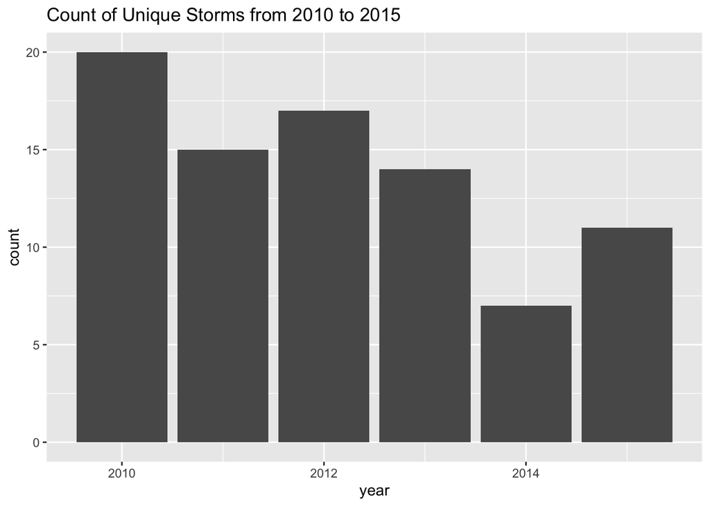

```r
ggplot(storm_names_2010s, aes(x = year)) + geom_bar() + ggtitle("Count of Unique Storms from 2010 to 2015")
```

2. Using the entire `storms` table, make a density graph for the variable `wind`, adding color to the border line, as well as the filling color of the density curve. Also, add a meaningful title to the plot. and choose the “Black-White” theme for the background of the graph.

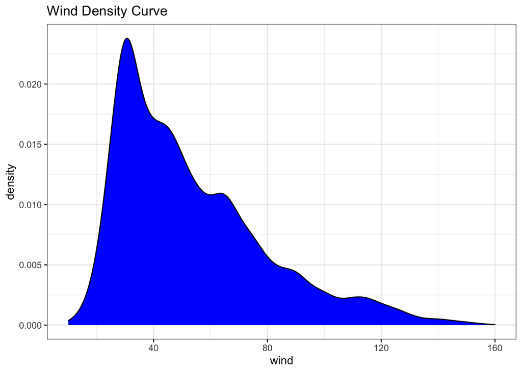

```r
ggplot(storms, aes(x = wind)) + geom_density(fill="blue") + ggtitle("Wind Density Curve") + theme(panel.background=element_rect(color="blue")) + theme_bw()
```

3. Make boxplots for the variable `pressure` of storms in each year during the period 2000 to 2011. Use facets for year (i.e. one facet per year). Also, add a meaningful title to the plot, and choose the “Minimal” theme for the background of the graph.

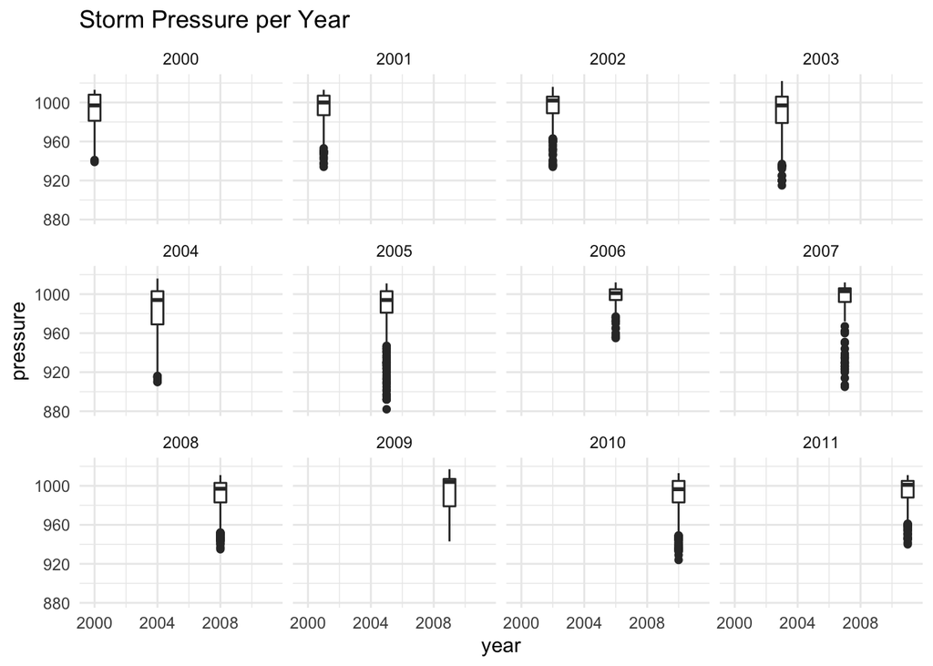

```r
storms_2000_to_2011 <- storms %>%
  filter(year >= 2000 & year <= 2011)

ggplot(storms_2000_to_2011, aes(x= year, y=pressure)) + geom_boxplot() + facet_wrap(year~.) + ggtitle("Storm Pressure per Year") + theme_minimal()
```

4. Using the entire `storms` table, graph a timeline of the median wind speed by year. This is: years in the x-axis, median wind-speed in the y-axis, timeline connecting the dots for median wind speed in each year. Also, add a meaningful title to the plot.

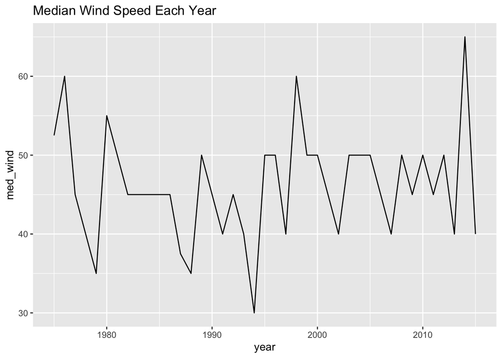

```r
med_wind_speeds <- storms %>%
  group_by(year) %>%
  mutate(med_wind = median(wind)) %>%
  distinct(year, med_wind)

ggplot(med_wind_speeds, aes(x=year, y=med_wind)) + geom_line() + ggtitle("Median Wind Speed Each Year")
```

### 5) Wind Speed and Pressure

1. With the entire `storms` table, use “ggplot2” functions to make a scatterplot of `wind` (axis) and `pressure` (y-axis). Because of the large number of dots, add an `alpha` value in order to make the dots somewhat transparent. Likewise, see how to add a “smoother” with the function `stat.smooth()`. Also, add a meaningful title to the plot.

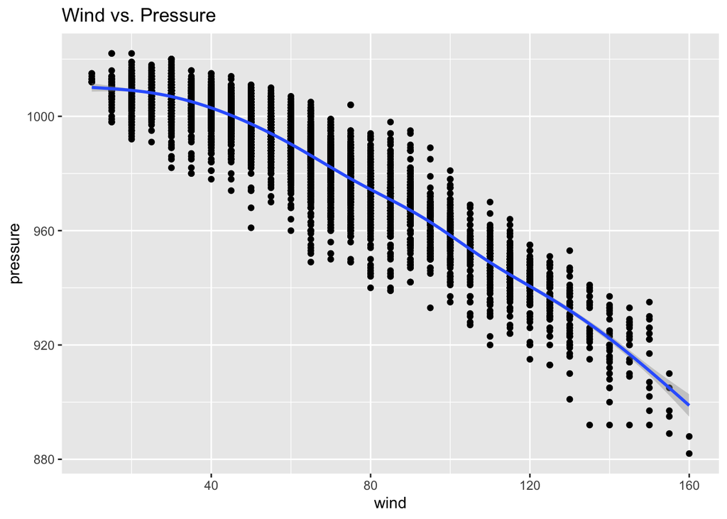

```r
ggplot(storms, aes(x=wind, y=pressure)) + geom_point(alpha=1) + stat_smooth() + ggtitle("Wind vs. Pressure")
```

2. With the entire `storms` table, use “ggplot2” functions to make the previous scatterplot of `wind` (x-axis) and `pressure` (y-axis). This time don’t include a smoother; instead use the variable `category` to color-code the dots in the scatterplot. Also, add a meaningful title to the plot.

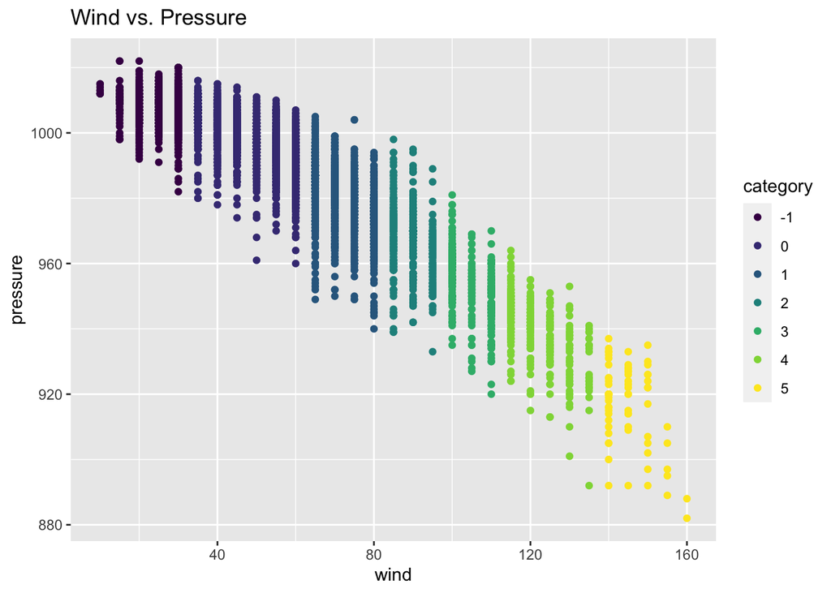

```r
ggplot(storms, aes(x=wind, y=pressure)) + geom_point(aes(color = category)) + ggtitle("Wind vs. Pressure")
```

### 6) Storm Categories

1. Use “dplyr” functions/commands to display, in ascending order, the different (unique) types of storm categories (using the entire `storms` table).

```r
storms %>%
  group_by(status) %>%
  distinct(status) %>%
  arrange(status)
```

```
## # A tibble: 3 × 1
## # Groups:   status [3]
##   status
##   <chr>
## 1 hurricane
## 2 tropical depression
## 3 tropical storm
```

2. With the entire `storms` table, use “dplyr” functions/commands to display a table showing the `category`, `avg_pressure` (average pressure), and `avg_wind` (average wind speed), for each type of storm category. This table should contain three columns: 1) `category`, 2) `avg_pressure`, and 3) `avg_wind`.

```r
storms %>%
  group_by(category) %>%
  mutate(avg_wind = mean(wind)) %>%
  mutate(avg_pressure = mean(pressure)) %>%
  distinct(category, avg_pressure, avg_wind) %>%
  arrange(category)
```

```
## # A tibble: 7 × 3
## # Groups:   category [7]
##   category avg_wind avg_pressure
##   <ord>       <dbl>        <dbl>
## 1 -1           27.3        1008.
## 2 0            45.8         999.
## 3 1            70.9         982.
## 4 2            89.4         967.
## 5 3           105.          954.
## 6 4           122.          940.
## 7 5           145.          916.
```

3. With the entire `storms` table, make a chart to visualize `pressure` in terms of the different category values. For example, you can either use histograms, or density curves, or boxplot, or violin plots. Add a meaningful title to the plot.

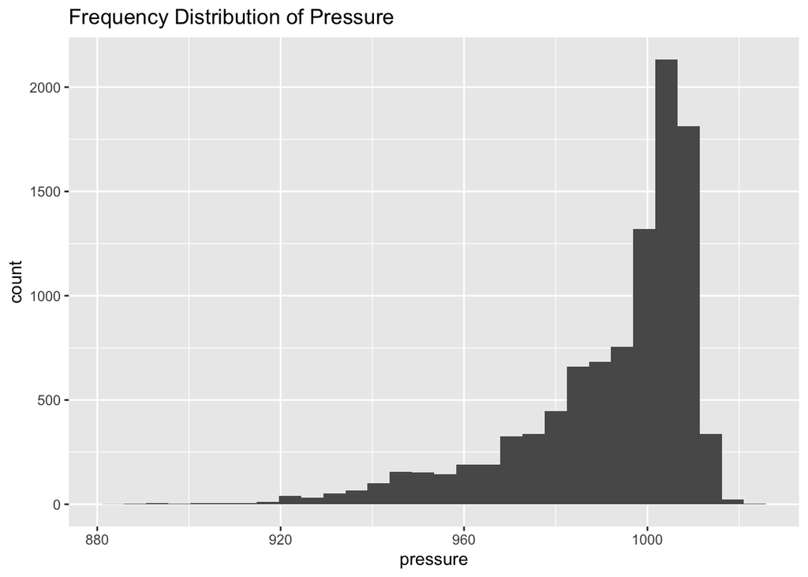

```r
ggplot(storms, aes(x = pressure)) + geom_histogram() + ggtitle("Frequency Distribution of Pressure")
```